# Tromp tweets

## Task 8: Instructions

Create the log odds ratio for each word.

1-After counting the occurrences of each word by its source, group by the word, and filter for words that occur at least five times in both platforms. 2-Use spread() to turn the row values of source into their columns. 3-Divide Android by iPhone and take the binary log of the ratio to create logratio. 4-Arrange the data in descending order of the logratio.

### HINT

A lot is going on in this task. Take it one step at a time.

If you’re trying to filter for words that occur at least ten times in both platforms, you will sum the occurrences and filter for those greater than or equal to ten, like so:

count(word, source) %>%  
group_by(word) %>% filter(sum(n) >= 10)

#9. Common words: Android vs. iPhone (ii) Now that we’ve calculated the log odds ratio of each word, we’ll plot the 15 words with the greatest log odds ratio for the Android and the iPhone. With the way we’ve set up the log odds ratio, positive values are assigned to words from the Android, and negative values are assigned to the iPhone.

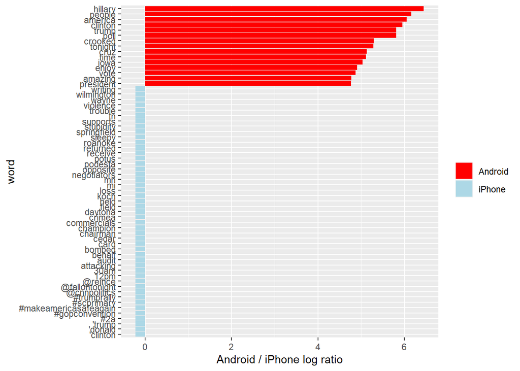

```r
# Plot the log odds ratio for each word by device
android_iphone_ratios %>%
  group_by(logratio > 0) %>%
  top_n(15, abs(logratio)) %>%
  ungroup() %>%
  mutate(word = reorder(word, logratio)) %>%
  ggplot(aes(word, logratio, fill = logratio < 0)) +
  geom_bar(stat = "identity") +
  coord_flip() +
  ylab("Android / iPhone log ratio") +
  scale_fill_manual(name = "", labels = c("Android", "iPhone"),
                    values = c("red", "lightblue"))
```

##Task 9: Instructions Plot the log odds ratios by device. 1-Group the data by positive and negative values. 2-Get the top 15 values of each group. 3-In the call to ggplot(), put the words on the x-axis and their log ratio on the y-axis. 4-Use the correct parameter in geom_bar() to map the height of the bar to the data value in y.

If you want to take the top positive and negative values from grouped variables, you might want to think about absolute values.

### HINT

If a variable is grouped, top_n() selects the top or bottom entries (if supplied a negative number) in each group and will include more than n rows if there are ties. To get the top 35 values of variable a that has been grouped by its sign (positive or negative), you need to take the absolute value of the variable like this:

data %>% group_by(a > 0) %>% top_n(35, abs(a)) %>% ungroup()

```r
# Create a sentiment data frame from the NRC lexicon
nrc <- read_rds("nrc.rds")

# Join the NRC lexicon to log odds ratio data frame
android_iphone_sentiment <- android_iphone_ratios %>%
  inner_join(nrc, by = "word") %>%
  filter(!sentiment %in% c("positive", "negative")) %>%
  mutate(sentiment = reorder(sentiment, -logratio),
         word = reorder(word, -logratio)) %>%
  group_by(sentiment) %>%
  top_n(10, abs(logratio)) %>%
  ungroup()

# Inspect the first six rows
head(android_iphone_sentiment)
```

```
## # A tibble: 6 × 5
##   word  Android iPhone logratio sentiment
##   <fct>   <dbl>  <dbl>    <dbl> <fct>
## 1 trump    1.03 0.0183     5.81 surprise
## 2 poll     1.10 0.0197     5.81 trust
## 3 time     1.54 0.0446     5.11 anticipation
## 4 enjoy    1.37 0.0455     4.91 anticipation
## 5 enjoy    1.37 0.0455     4.91 joy
## 6 enjoy    1.37 0.0455     4.91 trust
```

##Task 10: Instructions Add the NRC sentiment lexicon to the log odds ratio data frame.

1-Read in the NRC sentiment lexicon with read_rds(). 2-Use a join that will keep all the variables from android_iphone_ratios, and if there are multiple matches between android_iphone_ratios and nrc, all combinations of the matches will be returned. 3-Reorder the values of sentiment and word. 4-Take the top 10 values of each sentiment group.

### HINT

The type of join that will keep all the variables from x and all combinations of matches if there are multiple matches between x and x is an inner_join.

x %>% inner_join(y, by = “common_var”)

# 11. Android vs. iPhone sentiments

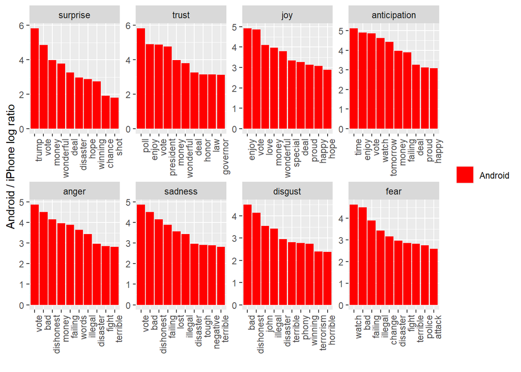

```r
# Plot the log odds ratio of words by device in groups sentiments
ggplot(android_iphone_sentiment, aes(word, logratio, fill = logratio < 0)) +
  facet_wrap(~ sentiment, scales = "free", nrow = 2) +
  geom_bar(stat = "identity") +
  theme(axis.text.x = element_text(angle = 90, hjust = 1)) +
  labs(x = "", y = "Android / iPhone log ratio") +
  scale_fill_manual(name = "", labels = c("Android", "iPhone"),
                    values = c("red", "lightblue"))
```

## Task 11: Instructions

Plot the log odds ratio of each word from both devices by sentiment.

1-Add the data frame and x and y aesthetics to plot the log odds ratio of each word. 2-Facet the data by sentiment and create two rows. 3-Use the correct parameter in geom_bar() to map the height of the bar to the data value in y.

### HINT

Facets in ggplot2 are subplots that each display one subset of the data. In a plot of x and y, you can subset the data by a grouped variable, z, into 3 rows of subplots like so:

ggplot(dataframe, aes(x, y,)) + facet_wrap(~ z, nrow = 3) + geom_point()

#12. Conclusion: The ghost in the political machine There’s a difference in style and sentiment between Trump’s tweets from the Android and the iPhone. We know Trump used the Android until March 2017, but who was tweeting from the iPhone on Trump’s behalf? let’s look together a New Yorker article about Tony Schwartz, Trump’s ghostwriter for The Art of the Deal (https://www.newyorker.com/magazine/2016/07/25/donald-trumps-ghostwriter-tells-all). Of particular interest was how Schwartz imitated Trump’s voice and philosophy:

“In his journal, Schwartz describes the process of trying to make Trump’s voice palatable in the book. It was kind of “a trick,” he writes, to mimic Trump’s blunt, staccato, no-apologies delivery while making him seem almost boyishly appealing…. Looking back at the text now, Schwartz says, “I created a character far more winning than Trump is.”

A lot has been written about Trump’s mental state. But I’d rather get inside the head of the anonymous staffer whose job is to imitate Trump’s unique cadence (“Very sad!”) or put a positive spin on it, to millions of his followers. Are they a true believer, or just a cog in a political machine, mixing whatever mainstream appeal they can into the @realDonaldTrump concoction? Like Tony Schwartz, will they one day regret their involvement?

## Task 12: Instructions

What do you think?

Pick one: “True Believer” or “Cog”

There is no wrong answer. You decide.